# Global Coronavirus Analysis

Luobin Chen, Yufei Zhang

5/17/2020

Introduction

The COVID-19 global pandemic has a major impact on people’s lives. The pandemic has ceased all forms of group gatherings to control transmission. The need to reconnect and recreate community is ever-present. On the purpose of analysis coronavirus, we find some simple ways to collect data on the confirmed cases, deaths, and nucleic acid tests from 1/22/2020 to 5/9/2020. In this project, we will tidy the data and make plots so we can visualize it clearly. We will analyze the dataset to create an interactive data map and see some patterns. By the end, we will try to gain some insight into how the confirmed cases are affected and determine the relationship between confirmed cases and deaths.

Loading and Plotting Data We find the data from Kaggle (https://www.kaggle.com/imdevskp/corona-virus-report?select=covid_19_clean_complete.csv). Now, We download the data and perform some simple plots to analyze the data. The first step is extracting the csv file then passing that to our data frame. Since we want to use the data for nucleic acids test(NAT) for further analysis, we download the data test.csv from Kaggle. (https://www.kaggle.com/imdevskp/corona-virus-report?select=tests.csv) We read the file using read_csv after importing essential library “tidyverse”. We renamed “Country/Region” to “Region” to be easier to reference.

```r
library(tidyverse)
df <- read_csv("covid_19_clean_complete.csv")
names(df)[1] <- "State"
names(df)[2] <- "Region"
df
```

```
## # A tibble: 30,210 x 8
##    State             Region         Lat   Long Date   Confirmed Deaths Recovered
##    <chr>             <chr>        <dbl>  <dbl> <chr>      <dbl>  <dbl>     <dbl>
##  1 <NA>              Afghanistan   33    65    1/22/…         0      0         0
##  2 <NA>              Albania       41.2  20.2  1/22/…         0      0         0
##  3 <NA>              Algeria       28.0   1.66 1/22/…         0      0         0
##  4 <NA>              Andorra       42.5   1.52 1/22/…         0      0         0
##  5 <NA>              Angola       -11.2  17.9  1/22/…         0      0         0
##  6 <NA>              Antigua and…  17.1 -61.8  1/22/…         0      0         0
##  7 <NA>              Argentina    -38.4 -63.6  1/22/…         0      0         0
##  8 <NA>              Armenia       40.1  45.0  1/22/…         0      0         0
##  9 Australian Capit… Australia    -35.5 149.   1/22/…         0      0         0
## 10 New South Wales   Australia    -33.9 151.   1/22/…         0      0         0
## # … with 30,200 more rows
```

```r
test <- read_csv("tests.csv")
head(test)
```

```
## # A tibble: 6 x 5
##   Country `Cases per 1M pop` `Deaths per 1M pop` `Total Tests` `Tests per 1M po…
##   <chr>                <dbl>               <dbl>         <dbl>             <dbl>
## 1 USA                   4327                 258      10287440             31080
## 2 Spain                 5831                 584       2467761             52781
## 3 Russia                1728                  16       6188102             42403
## 4 UK                    3434                 495       2219281             32691
## 5 Italy                 3673                 514       2735628             45246
## 6 Brazil                 904                  62        735224              3459
```

Now we have two essential data set for our analysis. First data set “df” has the information of confirmed cases, deaths, and recovered cases for every countries over the world from 1/22/20 to 5/09/2020. Additionally, it includes lat and long attributes for our interaction visualization. Second data set “test” has the information of ratio of confirmed cases, deaths, and NAT per 1 million population for each country.

Now let’s make some plot to have a general view of the data set. Initially, we want to plot all the confirmed cases for each country until 5/9/2020. However, because of a large amount of data, we can’t plot all the region attribute as color. There are too many data points which will make the x and y axis hard to see and analyze. Therefore, we first use arrange to sort data points by their confirmed cases. Then, we use slice command to slice out the top 15 countries that have the highest number of confirmed cases. We use group_by and sum command to get confirmed case for different regions/countries. The ungroup command is necessary for arrange command. We create a new data frame called “confirmed” which contains the information for the top 15 countries on the purpose of making the plot. The ggplot command helps us to make the plot. The data is from the first data set “df”. Here we map the Region attribute to the x position in the plot and the Confirmed_cases_for_country attribute to the y position in the plot. The ggplot contains the aes call. Here we choose points as the geometric representations of our chosen graphical characteristics using the geom_point function.

```r
# Confirmed case for top 20
confirmed <-  df %>%
  filter(Date=="5/9/20") %>%
  group_by(Region) %>%
  mutate(Confirmed_cases_for_country=sum(Confirmed)) %>%
  ungroup(Region) %>%
  arrange(desc(Confirmed_cases_for_country))

confirmed <- unique(data.frame(Region=confirmed$Region,Confirmed_cases_for_country=confirmed$Confirmed_cases_for_country))
confirmed
```

```
##                               Region Confirmed_cases_for_country
## 1                                 US                     1309550
## 2                              Spain                      223578
## 3                              Italy                      218268
## 4                     United Kingdom                      216525
## 15                            Russia                      198676
## 16                            France                      176782
## 27                           Germany                      171324
## 28                            Brazil                      156061
## 29                            Turkey                      137115
## 30                              Iran                      106220
## 31                             China                       83990
## 64                            Canada                       68918
## 78                              Peru                       65015
## 79                             India                       62808
```

[output cut: 174 more lines]

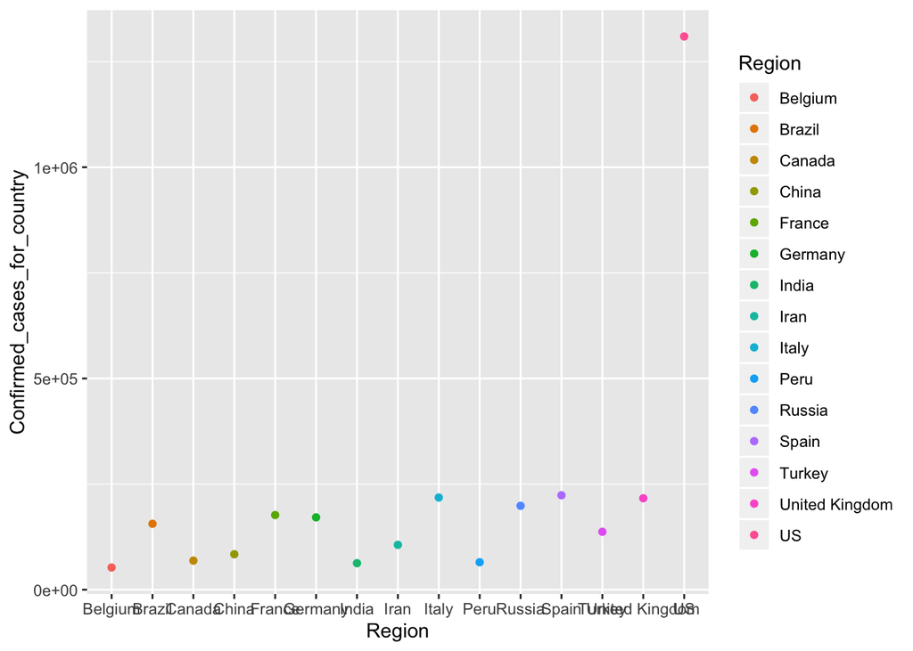

```r
confirmed %>%
  slice(1:15) %>%
  ggplot(mapping=aes(y=Confirmed_cases_for_country,x=Region,color=Region)) +
  geom_point()
```

From the plot, we can see the top 15 countries that have the highest number of confirmed cases clearly. They are US, Spain, Italy, United Kingdom, Russia, France, Germany, Brazil, Turkey, Iran, China, Canada, Peru, India, Belgium. We can see from the plot that the rate of confirmed cases in the United States is much higher than in other countries.

Now, we want to take advantage of the interaction visualization to make a more intuitive graph. We use the data form our data set “df”. We select all the data points from the last date which is 5/9/20. We use Leaflet library to generate the graph for each states or provinces. We learned from this website https://rstudio.github.io/leaflet/markers.html to generate useful icons. Base on our condition, states with less than 10000 confirmed cases have green popup icons. States with less than 50000 confirmed cases have orange popup icons. States will more than 50000 confirmed cases have red popup icons. These icons give us a better understanding of the distribution of corona virus. Additionally, it’s easier to see which area has the highest number of confirmed cases.

```r
df <- df %>%
  filter(Date=="5/9/20")
head(df)
```

```
## # A tibble: 6 x 8
##   State Region                Lat   Long Date   Confirmed Deaths Recovered
##   <chr> <chr>               <dbl>  <dbl> <chr>      <dbl>  <dbl>     <dbl>
## 1 <NA>  Afghanistan          33    65    5/9/20      4033    115       502
## 2 <NA>  Albania              41.2  20.2  5/9/20       856     31       627
## 3 <NA>  Algeria              28.0   1.66 5/9/20      5558    494      2546
## 4 <NA>  Andorra              42.5   1.52 5/9/20       754     48       545
## 5 <NA>  Angola              -11.2  17.9  5/9/20        43      2        13
## 6 <NA>  Antigua and Barbuda  17.1 -61.8  5/9/20        25      3        19
```

```r
library(leaflet)
getColor <- function(df) {
  sapply(df$Confirmed, function(Confirmed) {
  if(Confirmed <= 10000) {
    "green"
  } else if(Confirmed <= 50000) {
    "orange"
  } else {
    "red"
  } })
}
icons <- awesomeIcons(
  icon = 'ios-close',
  iconColor = 'black',
  library = 'ion',
  markerColor = getColor(df)
)
map <- leaflet(df) %>%
  addTiles() %>%
  addAwesomeMarkers(~Long,~Lat,popup=~as.character(Confirmed),icon=icons,label=~as.character(Confirmed))
map
```

[interactive chart not shown]

```r
names(test)[2] <- "Cases_per_1M_pop"
names(test)[3] <- "Deaths_per_1M_pop"
names(test)[4] <- "Total_Tests"
names(test)[5] <- "Tests_per_1M_pop"
test <- test %>%
  mutate(ratio=Cases_per_1M_pop/Tests_per_1M_pop)  %>%
  arrange(desc(ratio))
test %>% slice(1:50)
```

```
## # A tibble: 50 x 6
##    Country  Cases_per_1M_pop Deaths_per_1M_p… Total_Tests Tests_per_1M_pop ratio
##    <chr>               <dbl>            <dbl>       <dbl>            <dbl> <dbl>
##  1 Sao Tom…             1004             27           175              799 1.26
##  2 Algeria               143             12          6500              148 0.966
##  3 Equator…              372              4           854              609 0.611
##  4 Guinea-…              425              2          1500              762 0.558
##  5 Yemen                   2              0.4         120                4 0.5
##  6 Andorra              9836            634          1673            21653 0.454
##  7 Bolivia               270             12          7651              655 0.412
##  8 Honduras              228             12          5653              571 0.399
##  9 Cabo Ve…              520              4           791             1423 0.365
## 10 Ecuador              1728            132         87036             4933 0.350
## # … with 40 more rows
```

Tidy data

To make further analysis, We need to tidy data since there is some misunderstanding data and missing data. First we need to take care that the ratio of Sao Tome and Principe is larger than 1. How can Cases_per_1M_pop be larger than Tests_per_1M_pop? Maybe this region don’t have enough Nucleic Acid Detection Kit but some people have obvious symptoms of coronavirus so they are counted into cases. It shows its very weak test conditions. But we leave this data alone temporarily. Second, this data base miss some data of some countries so that we delete these countries’ data for accuracy of analysis.

```r
test <- test %>%
  filter(!is.na(Cases_per_1M_pop)) %>%
  filter(!is.na(Deaths_per_1M_pop)) %>%
  filter(!is.na(Total_Tests)) %>%
  filter(!is.na(Tests_per_1M_pop)) %>%
  filter(!is.na(ratio))
test
```

```
## # A tibble: 154 x 6
##    Country  Cases_per_1M_pop Deaths_per_1M_p… Total_Tests Tests_per_1M_pop ratio
##    <chr>               <dbl>            <dbl>       <dbl>            <dbl> <dbl>
##  1 Sao Tom…             1004             27           175              799 1.26
##  2 Algeria               143             12          6500              148 0.966
##  3 Equator…              372              4           854              609 0.611
##  4 Guinea-…              425              2          1500              762 0.558
##  5 Yemen                   2              0.4         120                4 0.5
##  6 Andorra              9836            634          1673            21653 0.454
##  7 Bolivia               270             12          7651              655 0.412
##  8 Honduras              228             12          5653              571 0.399
##  9 Cabo Ve…              520              4           791             1423 0.365
## 10 Ecuador              1728            132         87036             4933 0.350
## # … with 144 more rows
```

Now we have complete data for 154 countries and they are arranged in order from large ratio to small ratio.

First we are interested in the relationship between Deaths_per_1M_pop and Cases_per_1M_pop. Generally, it seems that more Cases_per_1M_pop will have more Deaths_per_1M_pop. We assume they have positive relationship and use Hypothesis Testing to test it.

Hypothesis Testing

Null Hypothesis: There is no relationship between cases rate and deaths rate. Alternative Hyporgesis: There is a relationship between cases rate and deaths rate.

```r
library(broom)
line <- lm(Deaths_per_1M_pop~Cases_per_1M_pop, data = test)
line
```

```
##
## Call:
## lm(formula = Deaths_per_1M_pop ~ Cases_per_1M_pop, data = test)
##
## Coefficients:
##      (Intercept)  Cases_per_1M_pop
##         -4.64668           0.05605
```

we can construct a 95% confidence interval to see how precise we think our estimates of the population regression line is.

```r
line_stats <- line %>%
  tidy() %>%
  select(term, estimate, std.error)
line_stats
```

```
## # A tibble: 2 x 3
##   term             estimate std.error
##   <chr>               <dbl>     <dbl>
## 1 (Intercept)       -4.65     8.89
## 2 Cases_per_1M_pop   0.0560   0.00354
```

```r
confidence_interval_offset <- 1.95 * line_stats$std.error[2]
confidence_interval <- round(c(line_stats$estimate[2] - confidence_interval_offset,
                               line_stats$estimate[2],
                               line_stats$estimate[2] + confidence_interval_offset), 4)
confidence_interval
```

```
## [1] 0.0492 0.0560 0.0629
```

```r
line_stats <- line %>%
  tidy()
line_stats
```

```
## # A tibble: 2 x 5
##   term             estimate std.error statistic  p.value
##   <chr>               <dbl>     <dbl>     <dbl>    <dbl>
## 1 (Intercept)       -4.65     8.89       -0.522 6.02e- 1
## 2 Cases_per_1M_pop   0.0560   0.00354    15.9   5.13e-34
```

Now we want to know how reliable this linear relationship is? We need to take a look at R-squared. R-squared is a statistical measure of how close the data are to the fitted regression line. R-squared is always between 0 and 1. Generally, the higher the R-squared, the better the model fits data.

```r
line %>%
  glance() %>%
  select(r.squared, sigma, statistic, df, p.value)
```

```
## # A tibble: 1 x 5
##   r.squared sigma statistic    df  p.value
##       <dbl> <dbl>     <dbl> <int>    <dbl>
## 1     0.623  96.5      251.     2 5.13e-34
```

The R-squared is 0.623. More than 62% of the variation in the outcome can be explained by independent variable. We can think the linear model is kind of reliable. Therefore, we can reject the null hypothesis “there is no relationship between cases rate and deaths rate.”

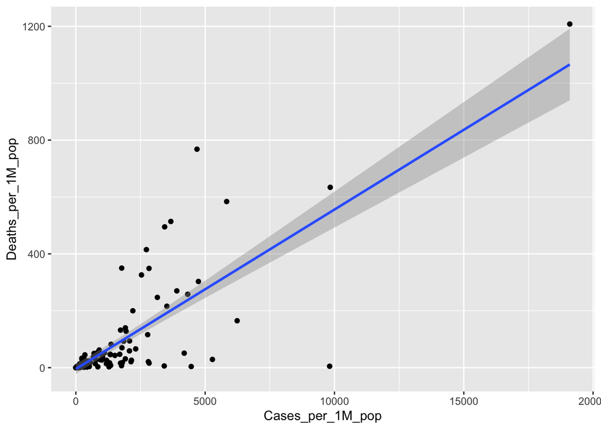

```r
test %>%
  ggplot(aes(x=Cases_per_1M_pop, y=Deaths_per_1M_pop)) +
  geom_point() +
  geom_smooth(method=lm)
```

Then we use augment function and make the polt to check the linearity.

Augument

```r
augmented_line <- line %>%
  augment()
augmented_line %>% head()
```

```
## # A tibble: 6 x 9
##   Deaths_per_1M_p… Cases_per_1M_pop .fitted .se.fit .resid    .hat .sigma
##              <dbl>            <dbl>   <dbl>   <dbl>  <dbl>   <dbl>  <dbl>
## 1             27               1004   51.6     7.81 -24.6  0.00656   96.8
## 2             12                143    3.37    8.66   8.63 0.00806   96.8
## 3              4                372   16.2     8.34 -12.2  0.00746   96.8
## 4              2                425   19.2     8.27 -17.2  0.00735   96.8
## 5              0.4                2   -4.53    8.89   4.93 0.00849   96.8
## 6            634               9836  547.     31.4   87.4  0.106     96.5
## # … with 2 more variables: .cooksd <dbl>, .std.resid <dbl>
```

check for linearity. If it is a linear relationship, the residuals wil cluster around 0.

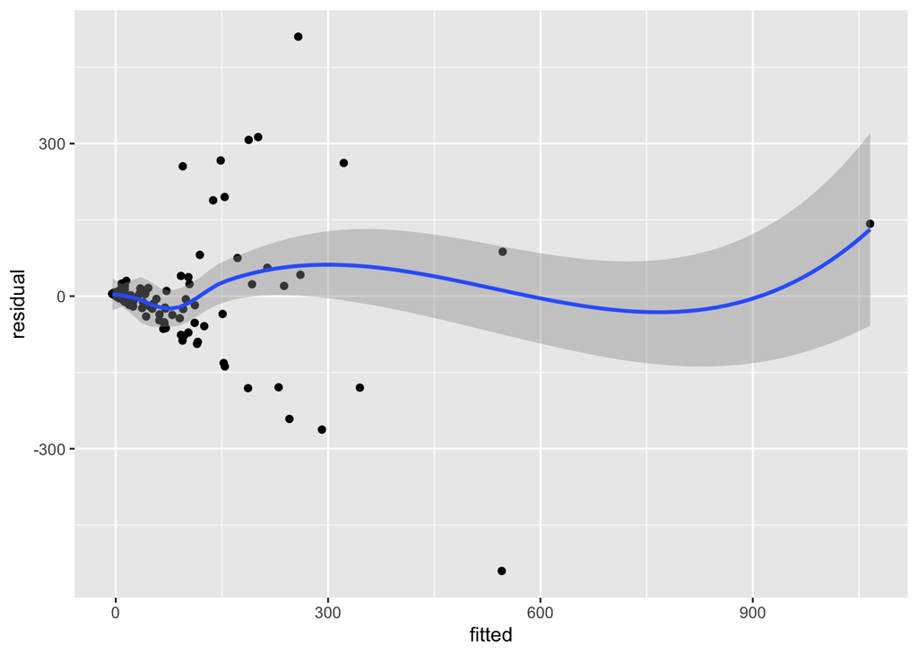

```r
augmented_line %>%
  ggplot(aes(x=.fitted,y=.resid)) +
    geom_point() +
    geom_smooth() +
    labs(x="fitted", y="residual")
```

The residuals cluster around 0, so there is a linear relationship between Deaths_per_1M_pop and Cases_per_1M_pop.

Second, as we mentioned before, if tests is enough for a country is an important question. The less ratio of Cases_per_1M_pop/Tests_per_1M_pop means heigher testing ability. The ratio(Cases_per_1M_pop/Tests_per_1M_pop) variable is not only related to a country ’s ability to control the epidemic, but also partially reflects a country ’s medical conditions. So we wonder if ratio has a relationship with Deaths_per_1M_pop. We use similar way to test it.

Let’s try Deaths_per_1M_pop and ratio(Cases_per_1M_pop/Tests_per_1M_pop)

Starting from linear regression.

Hypothesis Testing

```r
line_2 <- lm(Deaths_per_1M_pop~ratio, data = test)
line_2
```

```
##
## Call:
## lm(formula = Deaths_per_1M_pop ~ ratio, data = test)
##
## Coefficients:
## (Intercept)        ratio
##       51.86       113.08
```

we construct a 95% confidence interval to see how precise we think our estimates of the population regression line is.

```r
line_stats_2 <- line_2 %>%
  tidy() %>%
  select(term, estimate, std.error)
line_stats_2
```

```
## # A tibble: 2 x 3
##   term        estimate std.error
##   <chr>          <dbl>     <dbl>
## 1 (Intercept)     51.9      15.1
## 2 ratio          113.       78.2
```

```r
confidence_interval_offset_2 <- 1.95 * line_stats_2$std.error[2]
confidence_interval_2 <- round(c(line_stats_2$estimate[2] - confidence_interval_offset_2,
                               line_stats_2$estimate[2],
                               line_stats_2$estimate[2] + confidence_interval_offset_2), 4)
confidence_interval_2
```

```
## [1] -39.3558 113.0834 265.5225
```

```r
line_2 %>%
  glance() %>%
  select(r.squared, sigma, statistic, df, p.value)
```

```
## # A tibble: 1 x 5
##   r.squared sigma statistic    df p.value
##       <dbl> <dbl>     <dbl> <int>   <dbl>
## 1    0.0136  156.      2.09     2   0.150
```

Augument

```r
augmented_line_2 <- line_2 %>%
  augment()
augmented_line_2 %>% head()
```

```
## # A tibble: 6 x 9
##   Deaths_per_1M_p… ratio .fitted .se.fit .resid   .hat .sigma .cooksd .std.resid
##              <dbl> <dbl>   <dbl>   <dbl>  <dbl>  <dbl>  <dbl>   <dbl>      <dbl>
## 1             27   1.26     194.    90.8  -167. 0.339    156.  0.443      -1.32
## 2             12   0.966    161.    68.4  -149. 0.192    156.  0.134      -1.06
## 3              4   0.611    121.    41.4  -117. 0.0704   156.  0.0229     -0.777
## 4              2   0.558    115.    37.5  -113. 0.0577   156.  0.0170     -0.745
## 5              0.4 0.5      108.    33.3  -108. 0.0454   156.  0.0119     -0.708
## 6            634   0.454    103.    30.0   531. 0.0369   150.  0.230       3.47
```

check for possible non-linearity

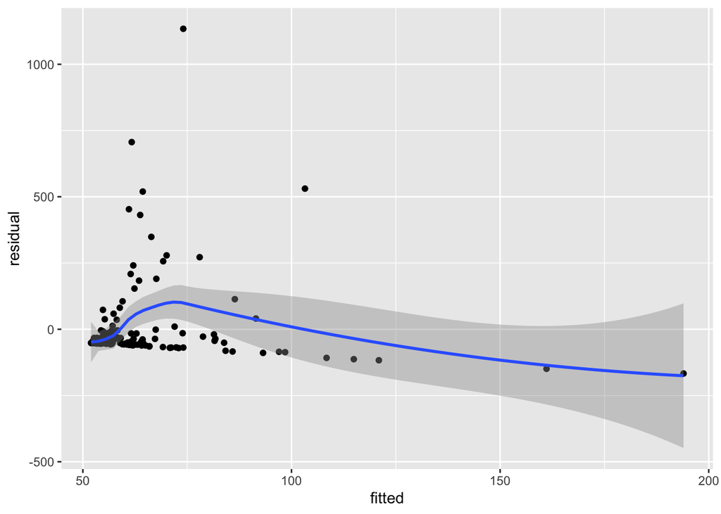

```r
augmented_line_2 %>%
  ggplot(aes(x=.fitted,y=.resid)) +
    geom_point() +
    geom_smooth() +
    labs(x="fitted", y="residual")
```

The residuals don’t cluster around 0 so that it also proves that there is no linear relationship between ratio(Cases_per_1M_pop/Tests_per_1M_pop) and deaths rate.

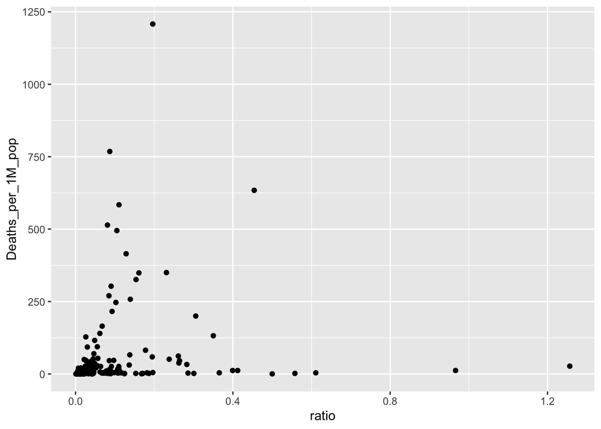

```r
test %>%
  ggplot(aes(x=ratio, y=Deaths_per_1M_pop)) +
  geom_point()
```

Although there is no linear relationship between ratio and death rate, from the distribution of data, we notice that the country having high death rate usually has low ratio, in other words, has relatively enough NAT.

Conclusion

We find the positive linear relationship between death rate and confirmed case rate. It follows natural and mathematical rules. However, we find no linear relationship between death rate and ratio(Cases_per_1M_pop/Tests_per_1M_pop). From the distribution of data(ratio and death rate), we also see the distribution don’t follow linear relationship. It makes sense. Different countries have great differences in population mobility, medical conditions, and control degress. For those countries having high death rate, they must urgently increase the testing rate to find the patients to cut off the propagation chain, so that they have relatively enough high NAT. For countries having relatively low death rate, ratio is various. But all mankind must work together to overcome the epidemic because no country can be alone.